# Cycle Route Uptake and Scenario Estimation Tool

For definitions of the scenarios and the routing algorithms we have used, see the FAQ.

# County level statistics

The population of Kildare is 222,504.

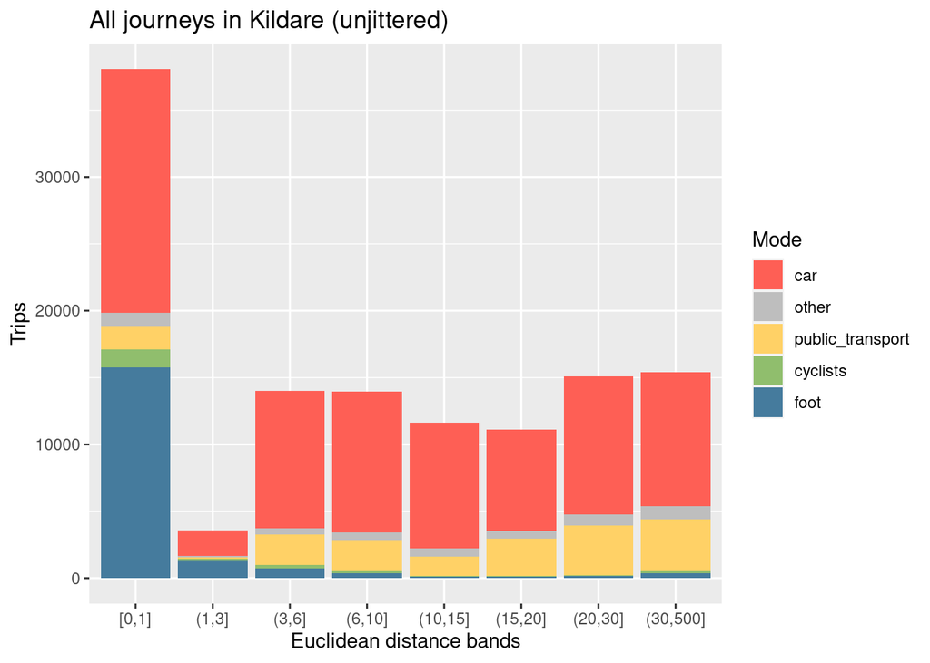

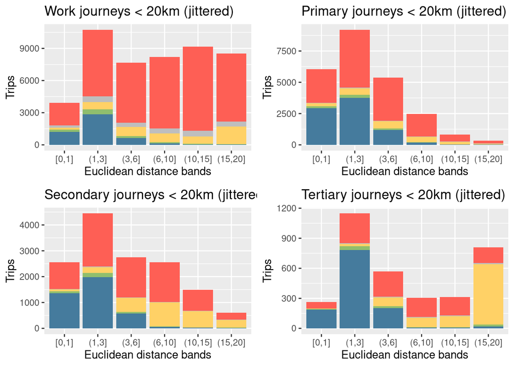

In Kildare, 122,750 work and educational journeys are made each day. Of the journeys that are <20 km in length, 48,242 are for travel to work, 24,257 for travel to primary schools, 14,409 are for travel to secondary schools and 3,410 are for travel to tertiary education.

The proportion of work and educational trips made by bike in each electoral division shows the geographic distribution of cycling based on the 2016 Census.

[interactive chart not shown]

# Scenario mode share and distance comparisons

## Trips to work

### Balanced routes

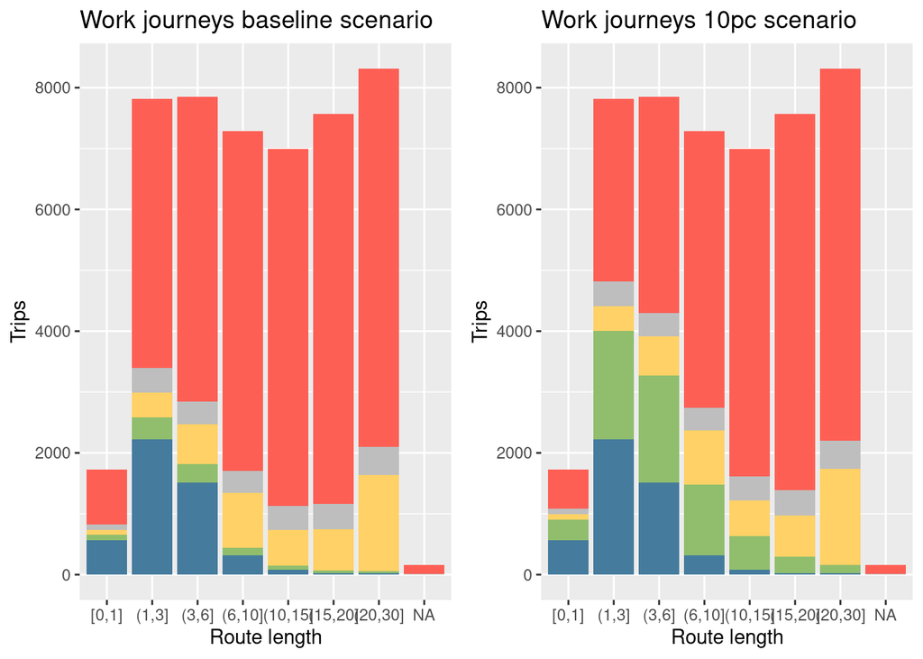

### Quietest routes

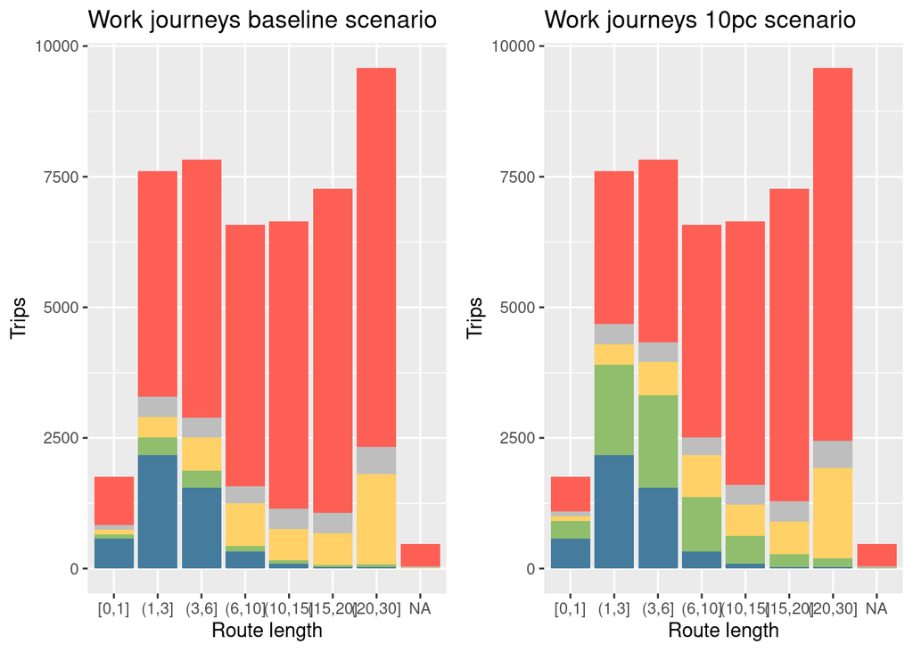

### Fastest routes

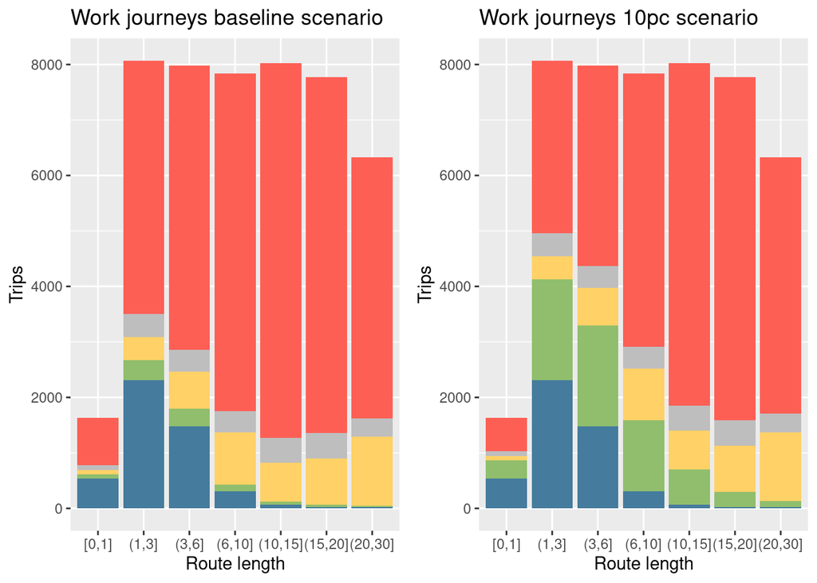

## Trips to primary schools

### Balanced routes

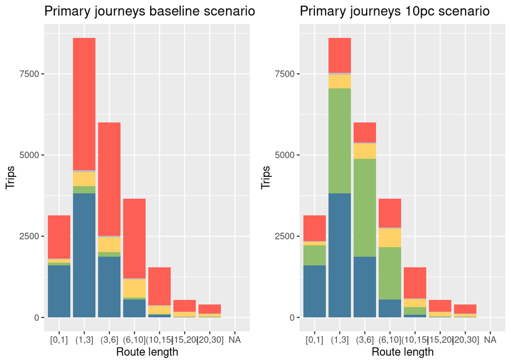

### Quietest routes

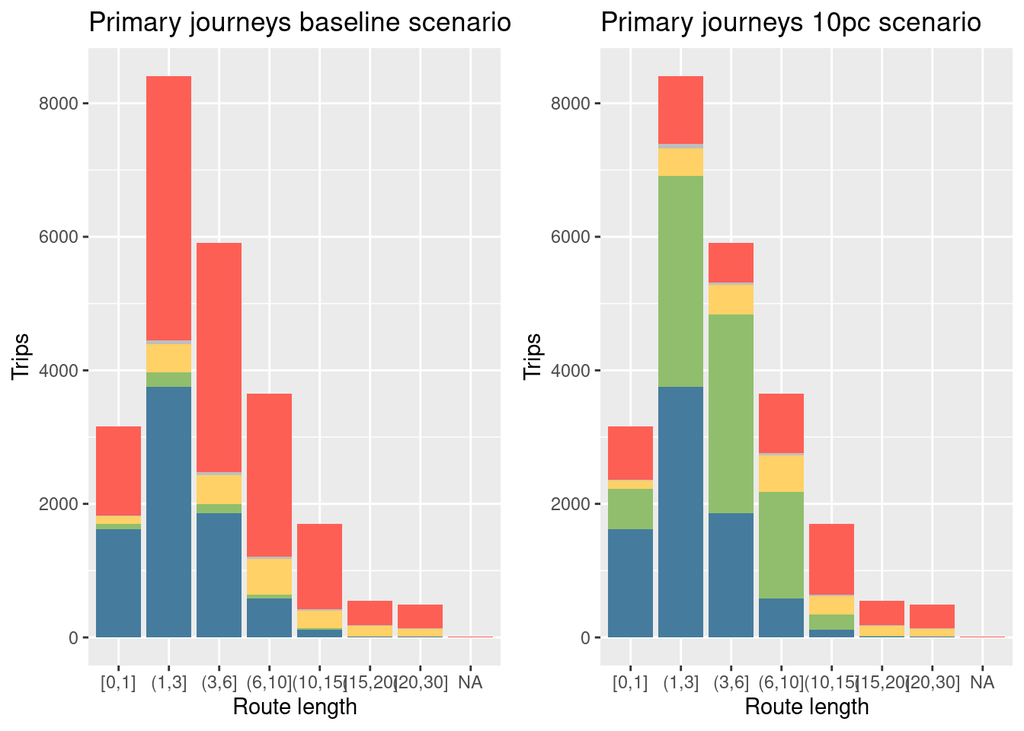

### Fastest routes

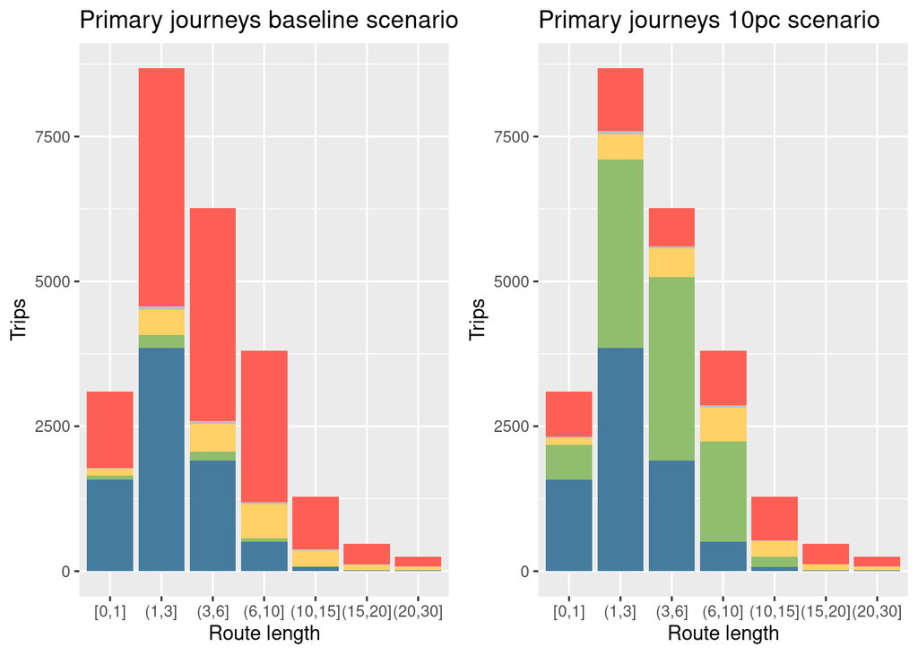

## Trips to secondary schools

### Balanced routes

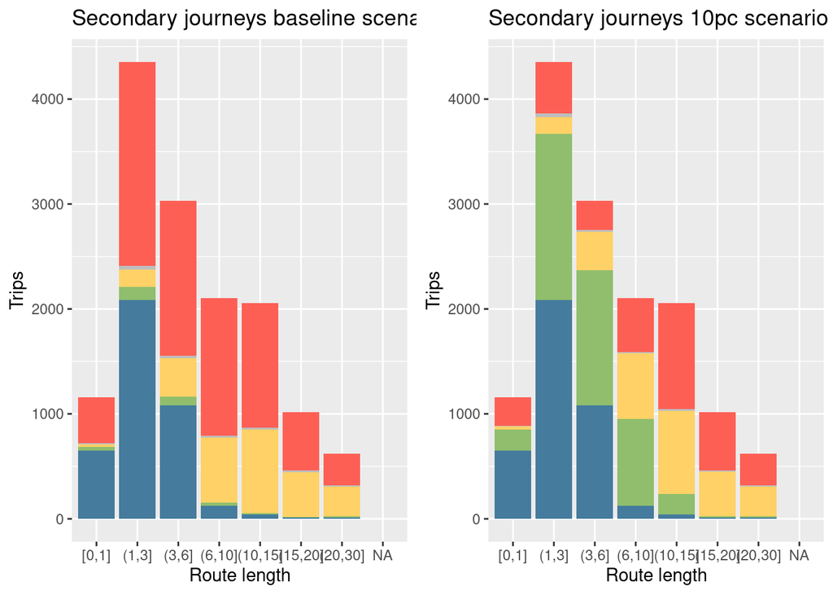

### Quietest routes

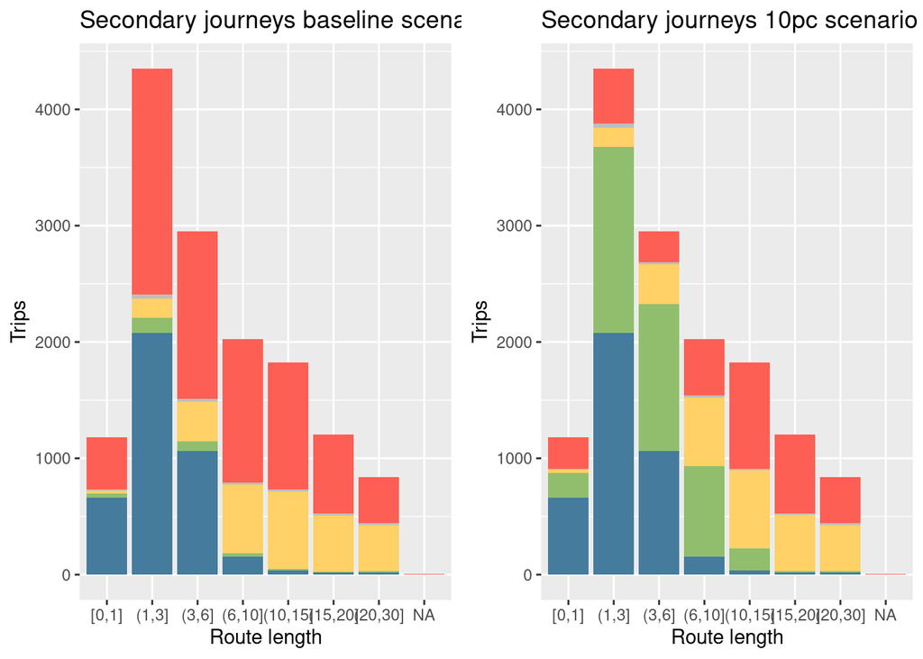

### Fastest routes

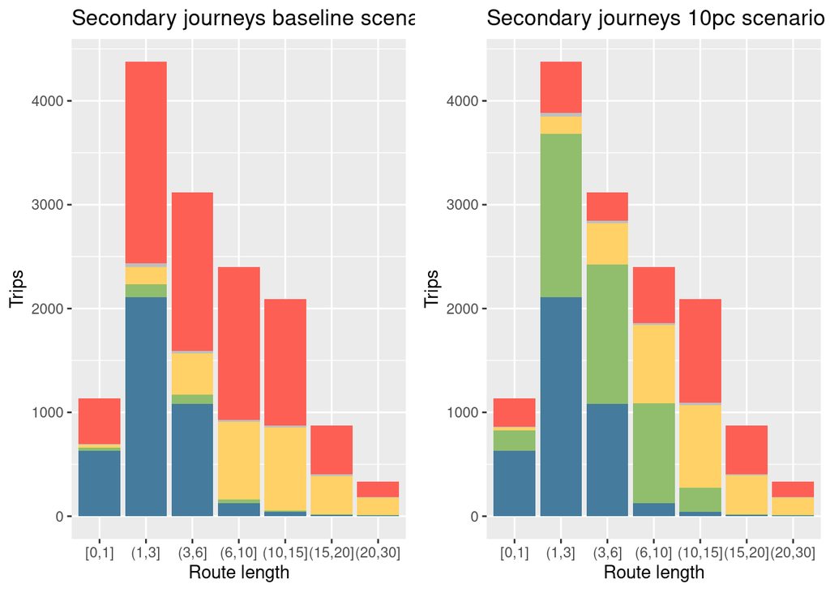

## Trips to tertiary educational establishments

### Balanced routes

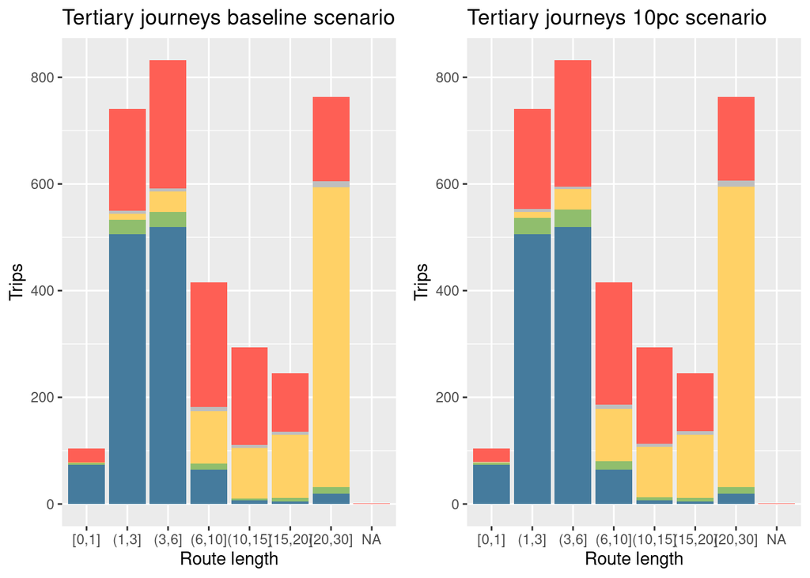

### Quietest routes

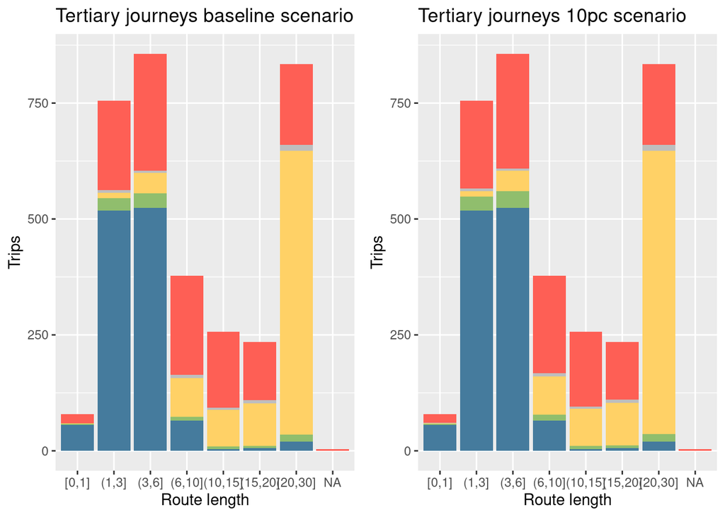

### Fastest routes

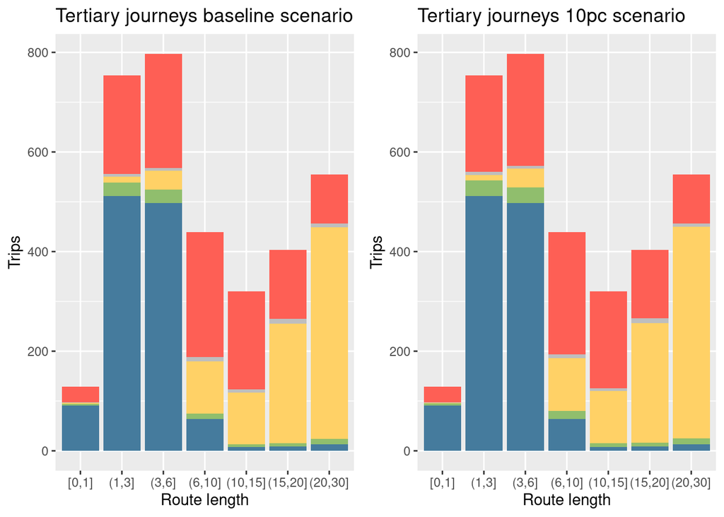

# Network maps

## Combined network - baseline scenario

[interactive chart not shown]

### Balanced route network

See full scale map here.

[interactive chart not shown]

### Quiet route network

See full scale map here.

[interactive chart not shown]

### Fast route network

See full scale map here.

[interactive chart not shown]

## Combined network - decarbonise scenario

Three versions of the combined route network under the decarbonise scenario are shown below. This involves mode shift from car to cycling, based on a ‘Go Dutch’ level of cycle uptake that mirrors cycle propensity in the Netherlands. The number of km driven by car are reduced by around 10%, in line with Irish Government’s Climate Action Plan.

### Balanced route network

See full scale map here.

[interactive chart not shown]

### Quiet route network

See full scale map here.

[interactive chart not shown]

### Fast route network

See full scale map here.

[interactive chart not shown]